# Dragon Curve Team - Group 2

```python
import matplotlib.pyplot as plt
import numpy as np
%matplotlib inline
```

For starters, let's establish what the two iterations of the dragon curve should look like

```python
#Curve 1
C1 = np.array([
    [0,0],
    [0,1]
])
```

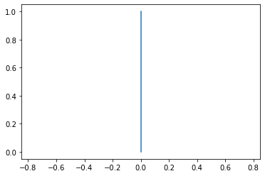

```python
plt.axis('equal')
plt.plot(C1[:, 0], C1[:, 1])
```

```python
#Curve 2
C2 = np.array([
    [0,1],
    [0,0],
    [-1,0]
])
```

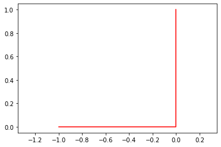

```python
plt.axis('equal')
plt.plot(C2[:, 0], C2[:, 1], color = 'red')
```

Now, let's construct a function that will plot the dragon curve at any iteration, with **kwargs

```python
def dcurve(n, cw, Y, c1 = 'blue', **kwargs):
    '''
    This function will accept 4 arguments, and return the nth iteration of the dragon curve. cw- denotes how much
    the next iteration will rotate. Y is an array that we clarify beforehand, and **kwargs is a wrapper intended allow
    the user to change the color of the rotation
    '''
    X = np.array ([
        [0,-1*cw],
        [cw,0]
    ])
    for i in range(1,n):
        Rotation = Y[::-1] @ X
        Y = np.concatenate([Y,Rotation[1:]])
        Y = Y - Y[len(Y) - 1]
        L = len(Y)
        Y1 = Y[:L//2 + 1]
        Y2 = Y[L - (L//2 + 1):]
    plt.plot(Y1[:,0], Y1[:, 1], c1)
    plt.plot(Y2[:,0], Y2[:, 1], **kwargs)
    plt.axis('equal')
    #print(Y, len(Y))
    plt.title('This is the dragon curve with ' +str(n) + ' iterations' )
```

So if the function is working properly, then the iteration should return 2 line segments, similar to what we have above if we input 2 as the argument for n, and -1 as the argument for cw

```python
#This is just some experimenting. I did to adjust the code as necessary
A = np.array([
    [1,1],
    [1,0],
    [0,0]
])
A[:2]
```

```
array([[1, 1],
       [1, 0]])
```

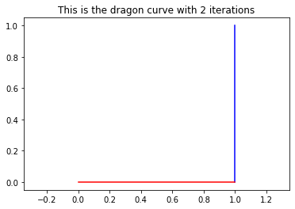

```python
Y = np.array([
    [0,1],
    [0,0]
])
dcurve(2, -1, Y, color = 'red')
```

Right now, the only problem with this is that the curve is reliant on the array being in a specific order, but right now we haven't come up with any ways to fix this issue.

For now, let's run the function through the 4, 8, and 16 iterations

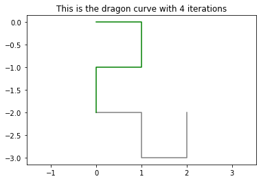

```python
#Curve with 4 iterations
dcurve(4, -1, Y, 'gray', color = 'green')
```

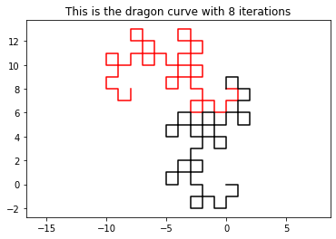

```python
#Curve with 8 iterations
dcurve(8, -1, Y, 'red', color = 'black')
```

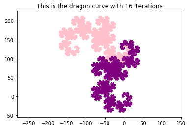

```python
#Curve with 16 iterations
dcurve(16, -1, Y, 'pink', color = 'purple')
```

Again, it's a bit awkward since the function is heavily reliant on the array being ordered in a certain way, but we can't think of any fixes for it at the moment.

Also, we couldn't figure out a way for kwargs to take multiple arguments for something like line color, which is why we could only set it so that the new line segments could be customized by kwargs, but the old lines can still be set as usual.